# Recent Probes MLMs

PD Inhibition Project

Nate Hall and Michael Hallquist

25 Apr 2020

# Load pre-cleaned data

In master_preproc.R, I determined to use the log-transformed RT distribution to fit to the data based on a group-based trimming procedure with all RTs > 3SD for group-level RT by condition being used as a criterion for dropping and any RTs <350 ms being dropped. This data set removes subjects with invalid personality profiles and subjects with undeniably flawed RT data (which in the case of the recent probes data isn’t anyone outside of the personality-dropped folks). Thus, we retain the core 104 subjects for analysis.

```r
recent_probes <- read.csv("~/github_repos/PD_Inhibition_DDM/Data/preprocessed/recent_probes_full_sample_nafilt_accCode.csv") %>% tibble()
str(recent_probes); length(unique(recent_probes$subj_idx))
```

```
## tibble [7,303 × 9] (S3: tbl_df/tbl/data.frame)
##  $ subj_idx       : int [1:7303] 1 1 1 1 1 1 1 1 1 1 ...
##  $ response       : int [1:7303] 1 1 1 1 1 1 1 1 1 1 ...
##  $ rt             : num [1:7303] 1.366 0.757 1.028 0.9 1.282 ...
##  $ stim           : Factor w/ 5 levels "negative_familiar",..: 4 5 3 5 5 5 5 3 1 5 ...
##  $ cond           : Factor w/ 2 levels "conflict","no_conflict": 2 2 1 2 2 2 2 1 1 2 ...
##  $ trial_z        : num [1:7303] -1.62 -1.57 -1.52 -1.47 -1.37 ...
##  $ trial          : int [1:7303] 1 2 3 4 6 8 9 10 11 12 ...
##  $ rt_log_trim_grp: num [1:7303] 3.14 2.88 3.01 2.95 3.11 ...
##  $ prev_rt        : num [1:7303] 1.132 1.366 0.757 1.028 1.739 ...
```

```
## [1] 104
```

```r
# re-order for simplicity of interpretation. Easier to consider non-conflict trials a baseline, that rts then deviate from as a result of conflict.
recent_probes$stim <- factor(recent_probes$stim, levels = c("positive", "negative_unfamiliar", "negative_familiar", "negative_highly_familiar", "negative_rc"))
recent_probes$cond <- factor(recent_probes$cond, levels = c("no_conflict", "conflict"))
```

Below is closely borrowed from MNH’s flanker_mlm.Rmd.

# Frequentist MLMs using maximum likelihood and no explicit temporal covariance

## m1: random intercept of subject, CS structure wrt trial

starting point in ML: random intercept of subject, compount symmetry residual correlation structure wrt trial

```r
m1 <- lme(rt_log_trim_grp ~ trial_z + stim, random = ~ 1 | subj_idx,
          correlation=corCompSymm(form=~trial|subj_idx), na.action = na.exclude,
          data = recent_probes, method='ML')

summary(m1)
```

```
## Linear mixed-effects model fit by maximum likelihood
##  Data: recent_probes
##      AIC    BIC logLik
##   -11235 -11173   5627
##
## Random effects:
##  Formula: ~1 | subj_idx
##         (Intercept) Residual
## StdDev:      0.0708    0.109
##
## Correlation Structure: Compound symmetry
##  Formula: ~trial | subj_idx
##  Parameter estimate(s):
## Rho
##   0
## Fixed effects: rt_log_trim_grp ~ trial_z + stim
##                               Value Std.Error   DF t-value p-value
## (Intercept)                   2.867   0.00718 7194     399   0.000
## trial_z                       0.014   0.00128 7194      11   0.000
## stimnegative_unfamiliar      -0.003   0.00404 7194      -1   0.404
## stimnegative_familiar         0.035   0.00406 7194       9   0.000
## stimnegative_highly_familiar  0.030   0.00405 7194       7   0.000
## stimnegative_rc               0.029   0.00405 7194       7   0.000
##  Correlation:
##                              (Intr) tril_z stmngtv_n stmngtv_f stmn__
## trial_z                       0.002
## stimnegative_unfamiliar      -0.113 -0.020
## stimnegative_familiar        -0.112 -0.019  0.200
## stimnegative_highly_familiar -0.112  0.029  0.199     0.198
## stimnegative_rc              -0.113  0.014  0.200     0.199     0.200
##
## Standardized Within-Group Residuals:
##     Min      Q1     Med      Q3     Max
## -3.5495 -0.6884 -0.0701  0.6011  4.5576
##
## Number of Observations: 7303
## Number of Groups: 104
```

```r
emmeans(m1, ~stim)
```

```
##  stim                     emmean      SE  df lower.CL upper.CL
##  positive                  2.867 0.00718 103    2.853    2.881
##  negative_unfamiliar       2.863 0.00783 103    2.848    2.879
##  negative_familiar         2.902 0.00784 103    2.887    2.918
##  negative_highly_familiar  2.897 0.00784 103    2.881    2.912
##  negative_rc               2.895 0.00783 103    2.880    2.911
##
## Degrees-of-freedom method: containment
## Confidence level used: 0.95
```

```r
x <- data.frame(emmeans(m1, ~stim))
#
# ggplot(x, aes(y = stim, x = emmean)) +
#   geom_point(shape = 21, size = 2, fill = "black") +
#   geom_errorbar(width = 0, aes(xmin = lower.CL, xmax=upper.CL))
```

## m2: simple random intercept model

Compound symmetry is already captured above by a simple variance component (G-side), which is why the CS correlation is zero in a model that has both.

This is discussed here: https://m-clark.github.io/mixed-models-with-R/extensions.html

Go back to a simple random intercept model.

```r
m2 <- lme(rt_log_trim_grp ~ trial_z + stim, random = ~ 1 | subj_idx,
          na.action = na.exclude,
          data = recent_probes, method='ML', control = lmeControl(opt="optim"))

summary(m2)
```

```
## Linear mixed-effects model fit by maximum likelihood
##  Data: recent_probes
##      AIC    BIC logLik
##   -11237 -11182   5627
##
## Random effects:
##  Formula: ~1 | subj_idx
##         (Intercept) Residual
## StdDev:      0.0708    0.109
##
## Fixed effects: rt_log_trim_grp ~ trial_z + stim
##                               Value Std.Error   DF t-value p-value
## (Intercept)                   2.867   0.00718 7194     399   0.000
## trial_z                       0.014   0.00128 7194      11   0.000
## stimnegative_unfamiliar      -0.003   0.00404 7194      -1   0.404
## stimnegative_familiar         0.035   0.00406 7194       9   0.000
## stimnegative_highly_familiar  0.030   0.00405 7194       7   0.000
## stimnegative_rc               0.029   0.00405 7194       7   0.000
##  Correlation:
##                              (Intr) tril_z stmngtv_n stmngtv_f stmn__
## trial_z                       0.002
## stimnegative_unfamiliar      -0.113 -0.020
## stimnegative_familiar        -0.112 -0.019  0.200
## stimnegative_highly_familiar -0.112  0.029  0.199     0.198
## stimnegative_rc              -0.113  0.014  0.200     0.199     0.200
##
## Standardized Within-Group Residuals:
##     Min      Q1     Med      Q3     Max
## -3.5495 -0.6884 -0.0701  0.6011  4.5576
##
## Number of Observations: 7303
## Number of Groups: 104
```

```r
anova(m1, m2)
```

```
##    Model df    AIC    BIC logLik   Test  L.Ratio p-value
## m1     1  9 -11235 -11173   5627
## m2     2  8 -11237 -11182   5627 1 vs 2 6.55e-11       1
```

```r
emmeans(m2, ~stim)
```

```
##  stim                     emmean      SE  df lower.CL upper.CL
##  positive                  2.867 0.00718 103    2.853    2.881
##  negative_unfamiliar       2.863 0.00783 103    2.848    2.879
##  negative_familiar         2.902 0.00784 103    2.887    2.918
##  negative_highly_familiar  2.897 0.00784 103    2.881    2.912
##  negative_rc               2.895 0.00783 103    2.880    2.911
##
## Degrees-of-freedom method: containment
## Confidence level used: 0.95
```

```r
#same log likelihood!
cat("LL(m1) - LL(m2)\n")
```

```
## LL(m1) - LL(m2)
```

```r
logLik(m1) - logLik(m2)
```

```
## 'log Lik.' 3.27e-11 (df=9)
```

## m3: R-side only CS model

Verify that an R-side only compound symmetry model matches variance component random intercept model. Need to use `gls` for this.

```r
#Here's the R-side only model with compound symmetry (no random intercept)
#this should also yield identical fit statistics -- just a reparameterization of the same approach
m3 <- gls(rt_log_trim_grp ~ trial_z + stim, correlation=corCompSymm(form=~trial|subj_idx), na.action = na.exclude,
          data = recent_probes, method='ML')

anova(m2, m3)
```

```
##    Model df    AIC    BIC logLik
## m2     1  8 -11237 -11182   5627
## m3     2  8 -11237 -11182   5627
```

```r
cat("LL(m3) - LL(m2)\n")
```

```
## LL(m3) - LL(m2)
```

```r
logLik(m3) - logLik(m2)
```

```
## 'log Lik.' 7.28e-12 (df=8)
```

```r
#look at model-predicted residual correlation structure

#R.a <- getVarCov(dental.lme.a,type="conditional",individual=1)
rcov <- getVarCov(m3, type="conditional", individual=1) #covariance matrix
rcorr <- cov2cor(getVarCov(m3, type="conditional",individual=1)) #residual correlation matrix for subj 1

#V_i <- getVarCov(m3, type="marginal", individual=1)
```

*Conclusion*: Confirmed that m1, m2, and m3 are isomorphic with each other. The conceptually simplest model is m2, the random intercept only model. Use this as the benchmark for increasingly complex models below

## m4: random intercept of subject, rather than split by exact trial type can try and simplify by looking at conflict vs no conflict

```r
m4 <- lme(rt_log_trim_grp ~ trial_z + cond, random=~1|subj_idx,
          na.action = na.exclude,
          data = recent_probes, method='ML')

summary(m4)
```

```
## Linear mixed-effects model fit by maximum likelihood
##  Data: recent_probes
##      AIC    BIC logLik
##   -11241 -11206   5625
##
## Random effects:
##  Formula: ~1 | subj_idx
##         (Intercept) Residual
## StdDev:      0.0708    0.109
##
## Fixed effects: rt_log_trim_grp ~ trial_z + cond
##              Value Std.Error   DF t-value p-value
## (Intercept)  2.866   0.00713 7197     402       0
## trial_z      0.014   0.00128 7197      11       0
## condconflict 0.032   0.00265 7197      12       0
##  Correlation:
##              (Intr) tril_z
## trial_z       0.000
## condconflict -0.139  0.018
##
## Standardized Within-Group Residuals:
##     Min      Q1     Med      Q3     Max
## -3.5424 -0.6900 -0.0687  0.6072  4.5632
##
## Number of Observations: 7303
## Number of Groups: 104
```

```r
#getVarCov(m4, "random.effects")

anova(m2, m4)
```

```
##    Model df    AIC    BIC logLik   Test L.Ratio p-value
## m2     1  8 -11237 -11182   5627
## m4     2  5 -11241 -11206   5625 1 vs 2    2.67   0.445
```

Looks like these models are roughly equivalent in their fit to the data, suggesting that perhaps the type of conflict does not quite matter but more the mere presence of cognitive interference significantly prolongs RTs.

## m5: allowing both cond and stim to have random intercepts within subject. E.g. heterogenous L2 random intercepts

```r
m5 <- lme(rt_log_trim_grp ~ trial_z + stim,
          random = list(subj_idx = pdDiag(~stim)),
          na.action = na.exclude,
          data = recent_probes, method='ML')

m6 <- lme(rt_log_trim_grp ~ trial_z + cond,
          random = list(subj_idx = pdDiag(~cond)),
          na.action = na.exclude,
          data = recent_probes, method='ML')

summary(m5)
```

```
## Linear mixed-effects model fit by maximum likelihood
##  Data: recent_probes
##      AIC    BIC logLik
##   -11230 -11147   5627
##
## Random effects:
##  Formula: ~stim | subj_idx
##  Structure: Diagonal
##         (Intercept) stimnegative_unfamiliar stimnegative_familiar stimnegative_highly_familiar stimnegative_rc Residual
## StdDev:      0.0708                1.14e-05                0.0119                       0.0114        7.73e-06    0.109
##
## Fixed effects: rt_log_trim_grp ~ trial_z + stim
##                               Value Std.Error   DF t-value p-value
## (Intercept)                   2.867   0.00718 7194     399   0.000
## trial_z                       0.014   0.00128 7194      11   0.000
## stimnegative_unfamiliar      -0.003   0.00404 7194      -1   0.404
## stimnegative_familiar         0.035   0.00422 7194       8   0.000
## stimnegative_highly_familiar  0.030   0.00420 7194       7   0.000
## stimnegative_rc               0.029   0.00404 7194       7   0.000
##  Correlation:
##                              (Intr) tril_z stmngtv_n stmngtv_f stmn__
## trial_z                       0.002
## stimnegative_unfamiliar      -0.113 -0.020
## stimnegative_familiar        -0.108 -0.018  0.192
## stimnegative_highly_familiar -0.108  0.028  0.192     0.183
## stimnegative_rc              -0.112  0.014  0.200     0.191     0.193
##
## Standardized Within-Group Residuals:
##     Min      Q1     Med      Q3     Max
## -3.5425 -0.6878 -0.0697  0.6012  4.5584
##
## Number of Observations: 7303
## Number of Groups: 104
```

```r
summary(m6)
```

```
## Linear mixed-effects model fit by maximum likelihood
##  Data: recent_probes
##      AIC    BIC logLik
##   -11241 -11200   5626
##
## Random effects:
##  Formula: ~cond | subj_idx
##  Structure: Diagonal
##         (Intercept) condconflict Residual
## StdDev:       0.071       0.0129    0.109
##
## Fixed effects: rt_log_trim_grp ~ trial_z + cond
##              Value Std.Error   DF t-value p-value
## (Intercept)  2.866   0.00714 7197     401       0
## trial_z      0.014   0.00128 7197      11       0
## condconflict 0.032   0.00293 7197      11       0
##  Correlation:
##              (Intr) tril_z
## trial_z       0.000
## condconflict -0.125  0.016
##
## Standardized Within-Group Residuals:
##     Min      Q1     Med      Q3     Max
## -3.5042 -0.6884 -0.0692  0.6072  4.5527
##
## Number of Observations: 7303
## Number of Groups: 104
```

```r
#getVarCov(m4, "random.effects")

anova(m4,m6)
```

```
##    Model df    AIC    BIC logLik   Test L.Ratio p-value
## m4     1  5 -11241 -11206   5625
## m6     2  6 -11241 -11200   5626 1 vs 2    2.36   0.124
```

```r
anova(m2,m5)
```

```
##    Model df    AIC    BIC logLik   Test L.Ratio p-value
## m2     1  8 -11237 -11182   5627
## m5     2 12 -11230 -11147   5627 1 vs 2   0.718   0.949
```

```r
m7 <- lme(rt_log_trim_grp ~ trial_z + stim,
          random = list(subj_idx = pdDiag(~cond)),
          na.action = na.exclude,
          data = recent_probes, method='ML')

summary(m7)
```

```
## Linear mixed-effects model fit by maximum likelihood
##  Data: recent_probes
##      AIC    BIC logLik
##   -11238 -11176   5628
##
## Random effects:
##  Formula: ~cond | subj_idx
##  Structure: Diagonal
##         (Intercept) condconflict Residual
## StdDev:       0.071       0.0129    0.109
##
## Fixed effects: rt_log_trim_grp ~ trial_z + stim
##                               Value Std.Error   DF t-value p-value
## (Intercept)                   2.867   0.00719 7194     399   0.000
## trial_z                       0.014   0.00128 7194      11   0.000
## stimnegative_unfamiliar      -0.003   0.00403 7194      -1   0.404
## stimnegative_familiar         0.035   0.00425 7194       8   0.000
## stimnegative_highly_familiar  0.030   0.00424 7194       7   0.000
## stimnegative_rc               0.028   0.00423 7194       7   0.000
##  Correlation:
##                              (Intr) tril_z stmngtv_n stmngtv_f stmn__
## trial_z                       0.002
## stimnegative_unfamiliar      -0.112 -0.020
## stimnegative_familiar        -0.107 -0.018  0.191
## stimnegative_highly_familiar -0.107  0.027  0.190     0.269
## stimnegative_rc              -0.107  0.013  0.191     0.270     0.271
##
## Standardized Within-Group Residuals:
##     Min      Q1     Med      Q3     Max
## -3.5111 -0.6882 -0.0699  0.6051  4.5470
##
## Number of Observations: 7303
## Number of Groups: 104
```

```r
anova(m5,m7)
```

```
##    Model df    AIC    BIC logLik   Test L.Ratio p-value
## m5     1 12 -11230 -11147   5627
## m7     2  9 -11238 -11176   5628 1 vs 2    1.65   0.648
```

```r
anova(m7, m6)
```

```
##    Model df    AIC    BIC logLik   Test L.Ratio p-value
## m7     1  9 -11238 -11176   5628
## m6     2  6 -11241 -11200   5626 1 vs 2    2.68   0.444
```

these are different parameterizations of the same model (or at least very close), though m6 with random intercepts estimated per subject and per condition provides the most parsimonious fit. I’d vote for moving forward with m6.

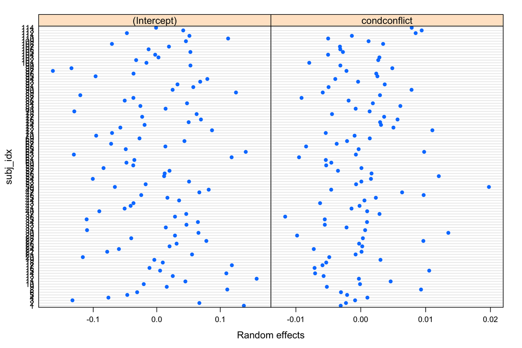

```r
vv <- ranef(m6)
# dotplot(ranef(m6))
plot(vv)
```

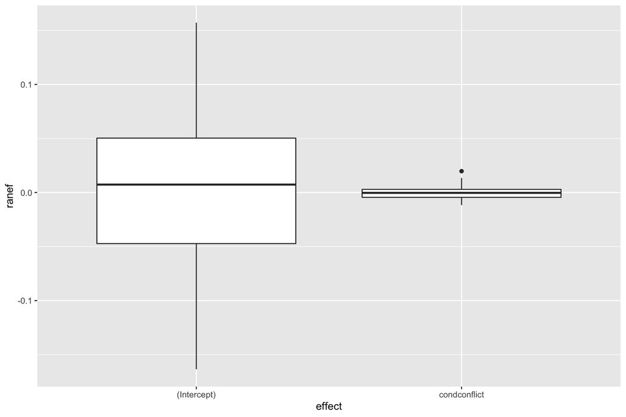

```r
vv %>% pivot_longer(cols = everything()) %>% ggplot(aes(x=name, y=value)) + geom_boxplot() + labs(y="ranef", x="effect")
```

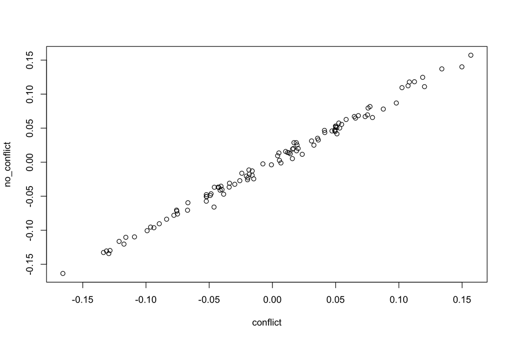

```r
estimated_ranef <- data.frame(
  conflict = vv[,"(Intercept)"] + vv[,"condconflict"],
  no_conflict = vv[,"(Intercept)"] #incongruent is reference condition
) %>% plot()
```

## m8: Heterogenous L1 variance for conditions, subject-specific intercept (homogenous) at L2 (similar to flanker m7).

This simply moves heterogeneous residuals for condition from G to R-side, (e.g. heterogeneity in condition residuals is the same across subjects)

```r
m8 <- lme(rt_log_trim_grp ~ trial_z + cond,
          weights = varIdent(form = ~1|cond),
          random = ~1|subj_idx,
          na.action = na.exclude,
          data = recent_probes, method='ML')

summary(m8)
```

```
## Linear mixed-effects model fit by maximum likelihood
##  Data: recent_probes
##      AIC    BIC logLik
##   -11239 -11197   5625
##
## Random effects:
##  Formula: ~1 | subj_idx
##         (Intercept) Residual
## StdDev:      0.0708    0.109
##
## Variance function:
##  Structure: Different standard deviations per stratum
##  Formula: ~1 | cond
##  Parameter estimates:
## no_conflict    conflict
##        1.00        1.01
## Fixed effects: rt_log_trim_grp ~ trial_z + cond
##              Value Std.Error   DF t-value p-value
## (Intercept)  2.866   0.00713 7197     402       0
## trial_z      0.014   0.00128 7197      11       0
## condconflict 0.032   0.00265 7197      12       0
##  Correlation:
##              (Intr) tril_z
## trial_z       0.000
## condconflict -0.138  0.018
##
## Standardized Within-Group Residuals:
##     Min      Q1     Med      Q3     Max
## -3.5485 -0.6896 -0.0681  0.6077  4.5726
##
## Number of Observations: 7303
## Number of Groups: 104
```

```r
anova(m6,m8)
```

```
##    Model df    AIC    BIC logLik
## m6     1  6 -11241 -11200   5626
## m8     2  6 -11239 -11197   5625
```

```r
AICtab(m8, m6, sort=TRUE, delta=TRUE, weights=TRUE, logLik=TRUE, base=TRUE)
```

```
##    logLik   AIC      dLogLik  dAIC     df weight
## m6   5626.5 -11241.0      1.1      0.0 6  0.76
## m8   5625.4 -11238.7      0.0      2.3 6  0.24
```

These seem nearly identical, which makes me think it’s preferable to favor m8, as it fixes L2 resids to be homogenous with respect to condition. Seems simpler if estimating G-side resid variance by subject doesnt lend a hand in model fit… I think that’s right?

## m9 add fixed effect for prev_rt to winning model

Seems a good a time as ever to include AR1 effects (or RT “Stickiness”)

```r
m9 <- lme(rt_log_trim_grp ~ trial_z + cond + prev_rt,
          weights = varIdent(form = ~1|cond),
          random = ~1|subj_idx,
          na.action = na.exclude,
          data = recent_probes, method='ML')

summary(m9)
```

```
## Linear mixed-effects model fit by maximum likelihood
##  Data: recent_probes
##      AIC    BIC logLik
##   -11240 -11192   5627
##
## Random effects:
##  Formula: ~1 | subj_idx
##         (Intercept) Residual
## StdDev:      0.0694    0.109
##
## Variance function:
##  Structure: Different standard deviations per stratum
##  Formula: ~1 | cond
##  Parameter estimates:
## no_conflict    conflict
##        1.00        1.01
## Fixed effects: rt_log_trim_grp ~ trial_z + cond + prev_rt
##              Value Std.Error   DF t-value p-value
## (Intercept)  2.858   0.00822 7196     348    0.00
## trial_z      0.014   0.00129 7196      11    0.00
## condconflict 0.032   0.00265 7196      12    0.00
## prev_rt      0.010   0.00533 7196       2    0.05
##  Correlation:
##              (Intr) tril_z cndcnf
## trial_z       0.062
## condconflict -0.153  0.010
## prev_rt      -0.526 -0.118  0.065
##
## Standardized Within-Group Residuals:
##     Min      Q1     Med      Q3     Max
## -3.5710 -0.6896 -0.0733  0.6073  4.5740
##
## Number of Observations: 7303
## Number of Groups: 104
```

```r
# anova(m8, m9)

AICtab(m8, m9, sort=TRUE, delta=TRUE, weights=TRUE, logLik=TRUE, base=TRUE)
```

```
##    logLik   AIC      dLogLik  dAIC     df weight
## m9   5627.2 -11240.5      1.9      0.0 7  0.71
## m8   5625.4 -11238.7      0.0      1.8 6  0.29
```

Looks like it doesn’t add much, this could maybe be due to the nature of the task. For example RTs are longest on this task meaning perhaps due to active maintenance required on this task. If participants are continually refreshing their WM buffer, it seems that trials may truly be more independent than on flanker and gng, which may have a sort of “momentum” to them.

For now, continue with random effects and perhaps re-introduce later in the model building procedure once random effects are parsed more finely. Though because of MNH’s comments around the fixed effects of his modeling efforts remaining relatively the same throughout his model building procedure, perhaps this truly is an effect that we may not care all that much about, esp if it just complicates our thinking later.

## m10 allow L1 and L2 heterogeneity in condition resid

```r
m10 <- lme(rt_log_trim_grp ~ trial_z + cond,
          weights = varIdent(form = ~1|cond),
          random = list(subj_idx = pdDiag(~cond)),
          na.action = na.exclude,
          data = recent_probes, method='ML')

summary(m10)
```

```
## Linear mixed-effects model fit by maximum likelihood
##  Data: recent_probes
##      AIC    BIC logLik
##   -11239 -11191   5627
##
## Random effects:
##  Formula: ~cond | subj_idx
##  Structure: Diagonal
##         (Intercept) condconflict Residual
## StdDev:       0.071       0.0128    0.109
##
## Variance function:
##  Structure: Different standard deviations per stratum
##  Formula: ~1 | cond
##  Parameter estimates:
## no_conflict    conflict
##           1           1
## Fixed effects: rt_log_trim_grp ~ trial_z + cond
##              Value Std.Error   DF t-value p-value
## (Intercept)  2.866   0.00714 7197     401       0
## trial_z      0.014   0.00128 7197      11       0
## condconflict 0.032   0.00293 7197      11       0
##  Correlation:
##              (Intr) tril_z
## trial_z       0.000
## condconflict -0.124  0.016
##
## Standardized Within-Group Residuals:
##    Min     Q1    Med     Q3    Max
## -3.509 -0.689 -0.069  0.607  4.559
##
## Number of Observations: 7303
## Number of Groups: 104
```

```r
anova(m8, m10)
```

```
##     Model df    AIC    BIC logLik   Test L.Ratio p-value
## m8      1  6 -11239 -11197   5625
## m10     2  7 -11239 -11191   5627 1 vs 2     2.3   0.129
```

```r
AICtab(m8, m9, m10, sort=TRUE, delta=TRUE, weights=TRUE, logLik=TRUE, base=TRUE)
```

```
##     logLik   AIC      dLogLik  dAIC     df weight
## m9    5627.2 -11240.5      1.9      0.0 7  0.53
## m10   5626.5 -11239.0      1.2      1.5 7  0.25
## m8    5625.4 -11238.7      0.0      1.8 6  0.22
```

looks like we’re fine with keeping residual variance associated with condition on the R-side

## m11: add random slope of trial

```r
m11 <- lme(rt_log_trim_grp ~ trial_z + cond,
          weights = varIdent(form = ~1|cond),
          random = ~1 + trial_z | subj_idx,
          na.action = na.exclude,
          data = recent_probes, method='ML')

summary(m11)
```

```
## Linear mixed-effects model fit by maximum likelihood
##  Data: recent_probes
##      AIC    BIC logLik
##   -11285 -11230   5651
##
## Random effects:
##  Formula: ~1 + trial_z | subj_idx
##  Structure: General positive-definite, Log-Cholesky parametrization
##             StdDev Corr
## (Intercept) 0.0709 (Intr)
## trial_z     0.0149 0.152
## Residual    0.1079
##
## Variance function:
##  Structure: Different standard deviations per stratum
##  Formula: ~1 | cond
##  Parameter estimates:
## no_conflict    conflict
##        1.00        1.01
## Fixed effects: rt_log_trim_grp ~ trial_z + cond
##              Value Std.Error   DF t-value p-value
## (Intercept)  2.866   0.00713 7197     402       0
## trial_z      0.014   0.00194 7197       7       0
## condconflict 0.032   0.00263 7197      12       0
##  Correlation:
##              (Intr) tril_z
## trial_z       0.112
## condconflict -0.136  0.012
##
## Standardized Within-Group Residuals:
##     Min      Q1     Med      Q3     Max
## -3.7481 -0.6765 -0.0764  0.5991  4.4241
##
## Number of Observations: 7303
## Number of Groups: 104
```

```r
anova(m8,m11)
```

```
##     Model df    AIC    BIC logLik   Test L.Ratio p-value
## m8      1  6 -11239 -11197   5625
## m11     2  8 -11285 -11230   5651 1 vs 2    50.3  <.0001
```

Looks like it does by quite a bit!

## m12: random slope of condition

```r
m12 <- lme(rt_log_trim_grp ~ trial_z + cond,
          weights = varIdent(form = ~1|cond),
          random = ~1 + trial_z + cond| subj_idx,
          na.action = na.exclude,
          data = recent_probes, method='ML',control = lmeControl(opt="optim"))

summary(m12)
```

```
## Linear mixed-effects model fit by maximum likelihood
##  Data: recent_probes
##      AIC    BIC logLik
##   -11287 -11211   5654
##
## Random effects:
##  Formula: ~1 + trial_z + cond | subj_idx
##  Structure: General positive-definite, Log-Cholesky parametrization
##              StdDev Corr
## (Intercept)  0.0721 (Intr) tril_z
## trial_z      0.0149  0.120
## condconflict 0.0160 -0.259  0.344
## Residual     0.1077
##
## Variance function:
##  Structure: Different standard deviations per stratum
##  Formula: ~1 | cond
##  Parameter estimates:
## no_conflict    conflict
##        1.00        1.01
## Fixed effects: rt_log_trim_grp ~ trial_z + cond
##              Value Std.Error   DF t-value p-value
## (Intercept)  2.866   0.00725 7197     395       0
## trial_z      0.014   0.00193 7197       7       0
## condconflict 0.032   0.00305 7197      11       0
##  Correlation:
##              (Intr) tril_z
## trial_z       0.088
## condconflict -0.244  0.143
##
## Standardized Within-Group Residuals:
##     Min      Q1     Med      Q3     Max
## -3.7121 -0.6780 -0.0729  0.5900  4.3956
##
## Number of Observations: 7303
## Number of Groups: 104
```

```r
anova(m11,m12)
```

```
##     Model df    AIC    BIC logLik   Test L.Ratio p-value
## m11     1  8 -11285 -11230   5651
## m12     2 11 -11287 -11211   5654 1 vs 2    7.49  0.0578
```

```r
AICtab(m11,m12, sort=TRUE, delta=TRUE, weights=TRUE, logLik=TRUE, base=TRUE)
```

```
##     logLik   AIC      dLogLik  dAIC     df weight
## m12   5654.3 -11286.5      3.7      0.0 11 0.68
## m11   5650.5 -11285.0      0.0      1.5 8  0.32
```

very modest change in model fit, could see it going either way, but in the spirit of capturing nuisance variation I say why not keep m12 which is only slightly more complicated but adds a tiny bit.

## m13: interaction of fixed effects?

```r
m13 <- lme(rt_log_trim_grp ~ trial_z * cond,
          weights = varIdent(form = ~1|cond),
          random = ~1 + trial_z + cond| subj_idx,
          na.action = na.exclude,
          data = recent_probes, method='ML',control = lmeControl(opt="optim"))

summary(m13)
```

```
## Linear mixed-effects model fit by maximum likelihood
##  Data: recent_probes
##      AIC    BIC logLik
##   -11285 -11202   5654
##
## Random effects:
##  Formula: ~1 + trial_z + cond | subj_idx
##  Structure: General positive-definite, Log-Cholesky parametrization
##              StdDev Corr
## (Intercept)  0.0721 (Intr) tril_z
## trial_z      0.0149  0.120
## condconflict 0.0160 -0.259  0.344
## Residual     0.1077
##
## Variance function:
##  Structure: Different standard deviations per stratum
##  Formula: ~1 | cond
##  Parameter estimates:
## no_conflict    conflict
##        1.00        1.01
## Fixed effects: rt_log_trim_grp ~ trial_z * cond
##                      Value Std.Error   DF t-value p-value
## (Intercept)          2.866   0.00725 7196     395   0.000
## trial_z              0.014   0.00216 7196       7   0.000
## condconflict         0.032   0.00305 7196      10   0.000
## trial_z:condconflict 0.000   0.00262 7196       0   0.896
##  Correlation:
##                      (Intr) tril_z cndcnf
## trial_z               0.079
## condconflict         -0.244  0.121
## trial_z:condconflict  0.001 -0.447  0.017
##
## Standardized Within-Group Residuals:
##     Min      Q1     Med      Q3     Max
## -3.7132 -0.6785 -0.0724  0.5912  4.3970
##
## Number of Observations: 7303
## Number of Groups: 104
```

```r
anova(m12, m13)
```

```
##     Model df    AIC    BIC logLik   Test L.Ratio p-value
## m12     1 11 -11287 -11211   5654
## m13     2 12 -11285 -11202   5654 1 vs 2  0.0166   0.897
```

okay, good that’s to be expected.

## m14: ixn of random slopes

```r
m14 <- lme(rt_log_trim_grp ~ trial_z + cond,
          weights = varIdent(form = ~1|cond),
          random = ~1 + trial_z * cond| subj_idx,
          na.action = na.exclude,
          data = recent_probes, method='ML',control = lmeControl(opt="optim"))

summary(m14)
```

```
## Linear mixed-effects model fit by maximum likelihood
##  Data: recent_probes
##      AIC    BIC logLik
##   -11281 -11178   5656
##
## Random effects:
##  Formula: ~1 + trial_z * cond | subj_idx
##  Structure: General positive-definite, Log-Cholesky parametrization
##                      StdDev  Corr
## (Intercept)          0.07197 (Intr) tril_z cndcnf
## trial_z              0.01669  0.128
## condconflict         0.01494 -0.275  0.394
## trial_z:condconflict 0.00601 -0.276 -0.844 -0.173
## Residual             0.10760
##
## Variance function:
##  Structure: Different standard deviations per stratum
##  Formula: ~1 | cond
##  Parameter estimates:
## no_conflict    conflict
##        1.00        1.01
## Fixed effects: rt_log_trim_grp ~ trial_z + cond
##              Value Std.Error   DF t-value p-value
## (Intercept)  2.866   0.00722 7197     397       0
## trial_z      0.014   0.00192 7197       7       0
## condconflict 0.032   0.00300 7197      11       0
##  Correlation:
##              (Intr) tril_z
## trial_z       0.068
## condconflict -0.248  0.165
##
## Standardized Within-Group Residuals:
##     Min      Q1     Med      Q3     Max
## -3.7339 -0.6787 -0.0776  0.5917  4.3216
##
## Number of Observations: 7303
## Number of Groups: 104
```

```r
anova(m12, m14)
```

```
##     Model df    AIC    BIC logLik   Test L.Ratio p-value
## m12     1 11 -11287 -11211   5654
## m14     2 15 -11281 -11178   5656 1 vs 2    2.93    0.57
```

sounds good.

## m15: try prev_rt one more time.

```r
m15 <- lme(rt_log_trim_grp ~ trial_z + cond + prev_rt,
          weights = varIdent(form = ~1|cond),
          random = ~1 + trial_z + cond| subj_idx,
          na.action = na.exclude,
          data = recent_probes, method='ML',control = lmeControl(opt="optim"))

summary(m15)
```

```
## Linear mixed-effects model fit by maximum likelihood
##  Data: recent_probes
##      AIC    BIC logLik
##   -11285 -11202   5654
##
## Random effects:
##  Formula: ~1 + trial_z + cond | subj_idx
##  Structure: General positive-definite, Log-Cholesky parametrization
##              StdDev Corr
## (Intercept)  0.0716 (Intr) tril_z
## trial_z      0.0147  0.117
## condconflict 0.0161 -0.261  0.348
## Residual     0.1077
##
## Variance function:
##  Structure: Different standard deviations per stratum
##  Formula: ~1 | cond
##  Parameter estimates:
## no_conflict    conflict
##        1.00        1.01
## Fixed effects: rt_log_trim_grp ~ trial_z + cond + prev_rt
##              Value Std.Error   DF t-value p-value
## (Intercept)  2.863   0.00840 7196     341   0.000
## trial_z      0.014   0.00193 7196       7   0.000
## condconflict 0.032   0.00307 7196      10   0.000
## prev_rt      0.004   0.00533 7196       1   0.468
##  Correlation:
##              (Intr) tril_z cndcnf
## trial_z       0.114
## condconflict -0.240  0.140
## prev_rt      -0.515 -0.079  0.056
##
## Standardized Within-Group Residuals:
##     Min      Q1     Med      Q3     Max
## -3.7149 -0.6763 -0.0747  0.5905  4.3984
##
## Number of Observations: 7303
## Number of Groups: 104
```

```r
AICtab(m15,m12, sort=TRUE, delta=TRUE, weights=TRUE, logLik=TRUE, base=TRUE)
```

```
##     logLik   AIC      dLogLik  dAIC     df weight
## m12   5654.3 -11286.5      0.0      0.0 11 0.68
## m15   5654.5 -11285.0      0.2      1.5 12 0.32
```

okay, yep definitely not :)

m12 seems very close to right even if we’re not carving nature right at its joints. call it a day for now. Better to try porting this to trait analysis, brms, and MPLUS.

brms version:

```r
m12 <- lme(rt_log_trim_grp ~ trial_z + cond,
          weights = varIdent(form = ~1|cond),
          random = ~1 + trial_z + cond| subj_idx,
          na.action = na.exclude,
          data = recent_probes, method='ML',control = lmeControl(opt="optim"))
tictoc::tic()
m12_brms <- brm(bf(rt_log_trim_grp ~ trial_z + cond +
          (1 + trial_z + cond  | subj_idx),
          sigma ~ cond), data = recent_probes, chains=4, cores=4, iter=3000)
```

```
## Trying to compile a simple C file
```

[output not shown]

```r
tictoc::toc()
```

```
## 881.943 sec elapsed
```

```r
beepr::beep()

summary(m12_brms)
```

```
##  Family: gaussian
##   Links: mu = identity; sigma = log
## Formula: rt_log_trim_grp ~ trial_z + cond + (1 + trial_z + cond | subj_idx)
##          sigma ~ cond
##    Data: recent_probes (Number of observations: 7303)
## Samples: 4 chains, each with iter = 3000; warmup = 1500; thin = 1;
##          total post-warmup samples = 6000
##
## Group-Level Effects:
## ~subj_idx (Number of levels: 104)
##                             Estimate Est.Error l-95% CI u-95% CI Rhat Bulk_ESS Tail_ESS
## sd(Intercept)                   0.07      0.01     0.06     0.09 1.00      822     1710
## sd(trial_z)                     0.02      0.00     0.01     0.02 1.00     3196     4523
## sd(condconflict)                0.01      0.01     0.00     0.02 1.00      941     1080
## cor(Intercept,trial_z)          0.12      0.13    -0.14     0.36 1.00     4943     4679
## cor(Intercept,condconflict)    -0.26      0.25    -0.73     0.25 1.00     6367     2906
## cor(trial_z,condconflict)       0.40      0.29    -0.28     0.89 1.00     2783     3266
##
## Population-Level Effects:
##                    Estimate Est.Error l-95% CI u-95% CI Rhat Bulk_ESS Tail_ESS
## Intercept              2.87      0.01     2.85     2.88 1.01      519      944
## sigma_Intercept       -2.23      0.01    -2.25    -2.21 1.00    13899     4208
## trial_z                0.01      0.00     0.01     0.02 1.00     5589     4754
## condconflict           0.03      0.00     0.03     0.04 1.00     8597     5172
## sigma_condconflict     0.01      0.02    -0.02     0.04 1.00    14736     4448
##
## Samples were drawn using sampling(NUTS). For each parameter, Bulk_ESS
## and Tail_ESS are effective sample size measures, and Rhat is the potential
## scale reduction factor on split chains (at convergence, Rhat = 1).
```

```r
summary(pairs(emmeans(m12_brms, ~cond)))
```

```
##  contrast               estimate lower.HPD upper.HPD
##  no_conflict - conflict   -0.032    -0.038   -0.0265
##
## Point estimate displayed: median
## HPD interval probability: 0.95
```

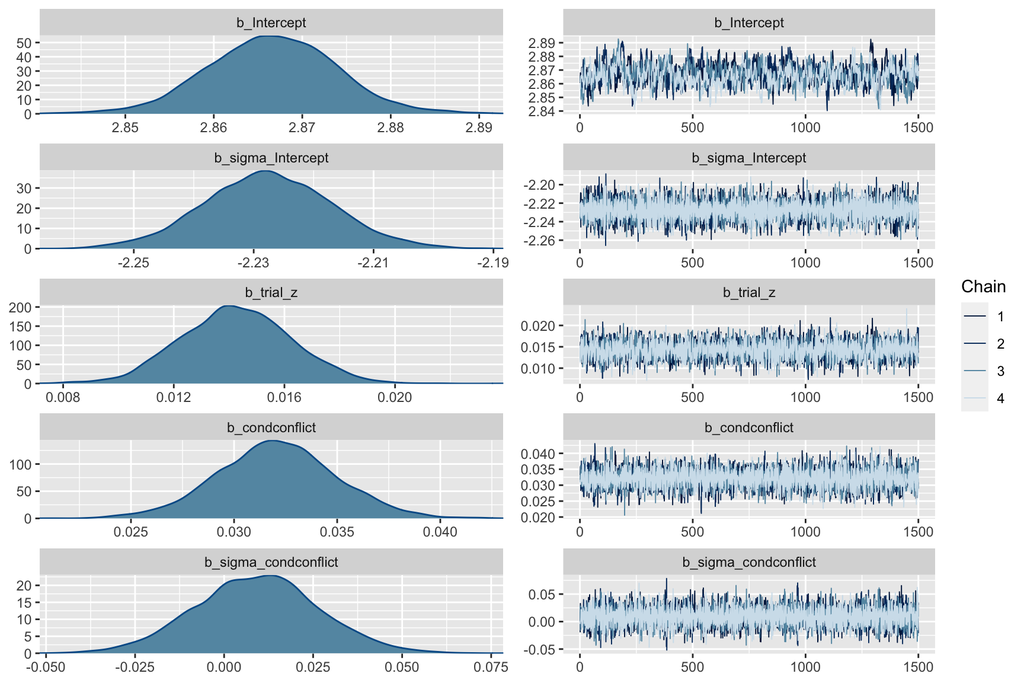

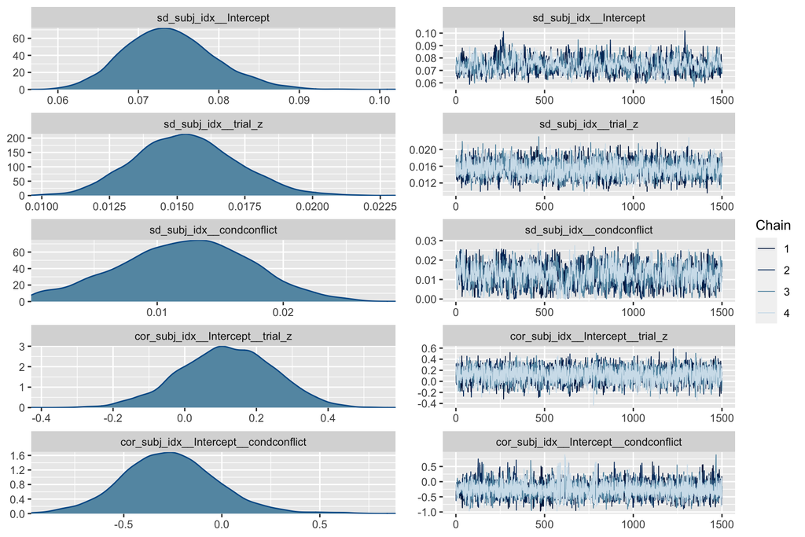

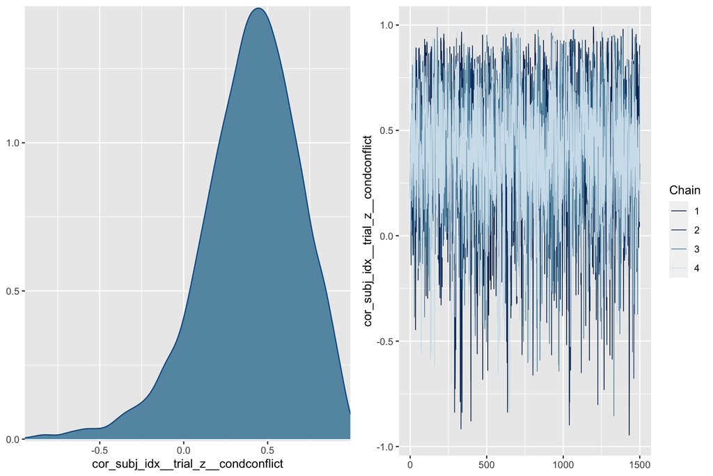

```r
plot(m12_brms)
```